# Coursera Practical Machine Learning - Course Project

Torsten Nahm

Oct 15, 2016

**Credits**

This course project uses the Weight Lifting Exercises Dataset available at http://groupware.les.inf.puc-rio.br/har. The corresponding paper is at http://groupware.les.inf.puc-rio.br/public/papers/2013.Velloso.QAR-WLE.pdf.

### Exploratory analysis

I load the data file and look at its structure, the outcome distribution and some features.

```r
data0 <- read.csv("pml-training.csv",row.names=1)
names(data0)[1:20]
```

```
##  [1] "user_name"            "raw_timestamp_part_1" "raw_timestamp_part_2"
##  [4] "cvtd_timestamp"       "new_window"           "num_window"
##  [7] "roll_belt"            "pitch_belt"           "yaw_belt"
## [10] "total_accel_belt"     "kurtosis_roll_belt"   "kurtosis_picth_belt"
## [13] "kurtosis_yaw_belt"    "skewness_roll_belt"   "skewness_roll_belt.1"
## [16] "skewness_yaw_belt"    "max_roll_belt"        "max_picth_belt"
## [19] "max_yaw_belt"         "min_roll_belt"
```

```r
table(data0$classe)
```

```
##
##    A    B    C    D    E
## 5580 3797 3422 3216 3607
```

```r
table(data0$user_name,data0$classe)
```

```
##
##               A    B    C    D    E
##   adelmo   1165  776  750  515  686
##   carlitos  834  690  493  486  609
##   charles   899  745  539  642  711
##   eurico    865  592  489  582  542
##   jeremy   1177  489  652  522  562
##   pedro     640  505  499  469  497
```

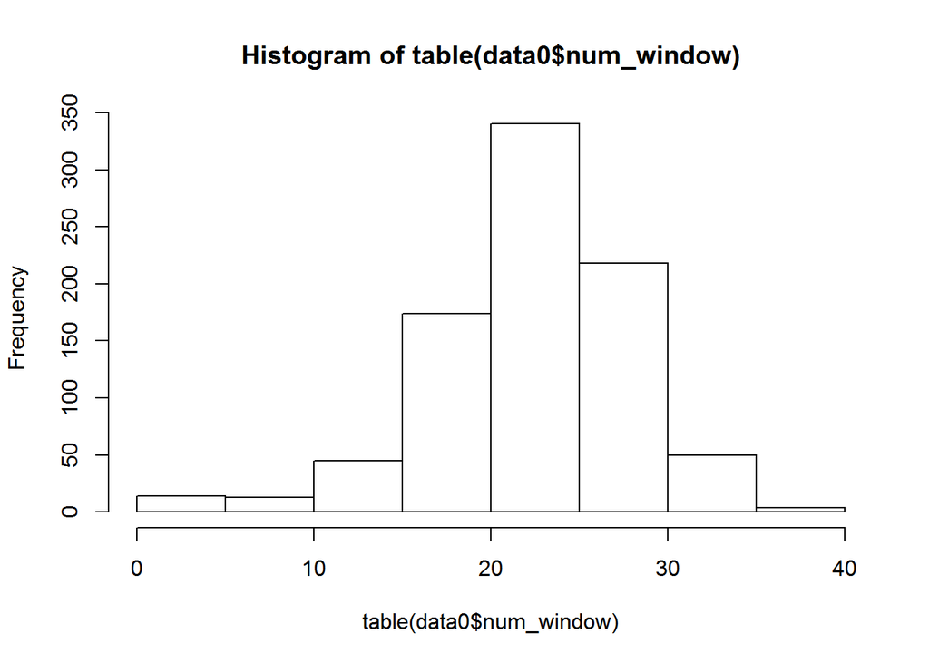

```r
hist(table(data0$num_window))
```

It looks like the data comes from time windows with different lengths. However, I ignore the temporal structure of the data for this exercise, and learn only on the individual observations.

I now look at the structure of the data, and particularly look for missing values.

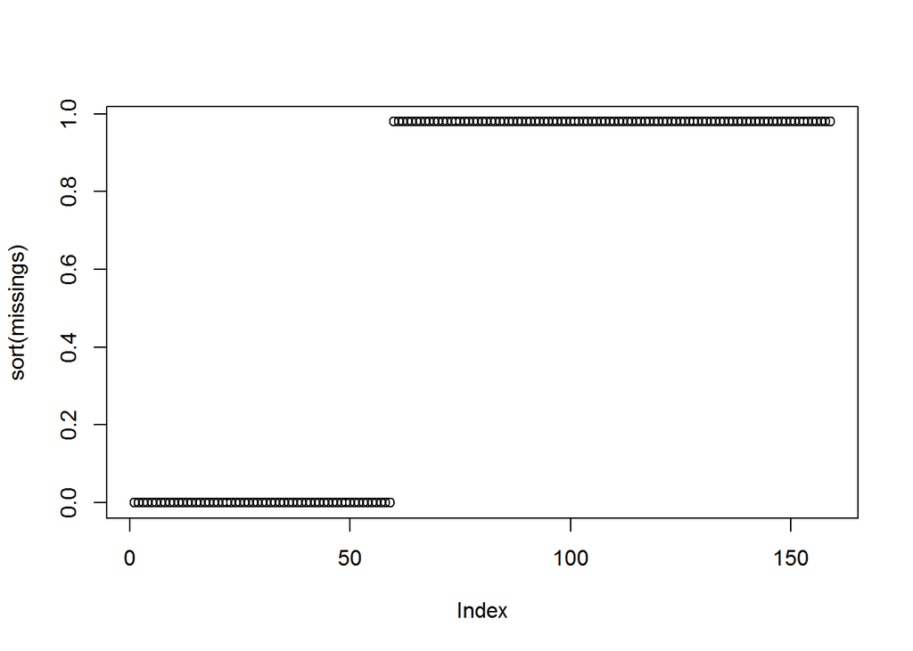

```r
missings <- sapply(data0,function(x) mean(is.na(x)|x==""))
plot(sort(missings))
```

I see that some features are 100% complete, others have a very high proportion of missings.

```r
table(is.na(data0$var_pitch_forearm),data0$new_window)
```

```
##
##            no   yes
##   FALSE     0   406
##   TRUE  19216     0
```

It looks like the features with high missings are summary statistics associated with new time windows.

I remove all features with a high proportion of missings. I also remove the user name and timestamps from the data set, as these should not be used for training.

```r
data <- data0[,missings < 0.5][,-(1:6)]
dim(data)
```

```
## [1] 19622    53
```

### Analysis and training

Now we are ready to start the analysis.

I try the random forest method first, as it is usually robust with feature rich and noisy data. Because of run time constraints, I limit the number of trees, using `ntree=100`.

I split up the data set using 10-fold cross-validation along the outcome variable `classe`. This will allow me to get a robust estimate on the out-of-sample error.

I set a seed for the random number generator to make the results reproducible.

```r
library(caret)
library(randomForest)
n <- which(names(data)=="classe")

set.seed(123)
partition <- createFolds(data$classe,k=10)

res <- factor(rep(NA,nrow(data)),levels(data$classe))

for (p in partition) {
    train <- data[p,]
    test <- data[-p,]
    mod.rf <- randomForest(classe ~ .,data=train,ntree=100)
    pred.rf <- predict(mod.rf,newdata=test)
    res[-p] <- pred.rf
}

confusionMatrix(res,data$classe)
```

```
## Confusion Matrix and Statistics
##
##           Reference
## Prediction    A    B    C    D    E
##          A 5498  227    4   27    6
##          B   32 3455  190    2   33
##          C   32  106 3206  181   88
##          D   14    5   22 2990   64
##          E    4    4    0   16 3416
##
## Overall Statistics
##
##                Accuracy : 0.9461
##                  95% CI : (0.9429, 0.9492)
##     No Information Rate : 0.2844
##     P-Value [Acc > NIR] : < 2.2e-16
##
##                   Kappa : 0.9318
##  Mcnemar's Test P-Value : < 2.2e-16
##
## Statistics by Class:
##
##                      Class: A Class: B Class: C Class: D Class: E
## Sensitivity            0.9853   0.9099   0.9369   0.9297   0.9470
## Specificity            0.9812   0.9838   0.9749   0.9936   0.9985
## Pos Pred Value         0.9542   0.9308   0.8874   0.9661   0.9930
## Neg Pred Value         0.9941   0.9785   0.9865   0.9863   0.9882
## Prevalence             0.2844   0.1935   0.1744   0.1639   0.1838
## Detection Rate         0.2802   0.1761   0.1634   0.1524   0.1741
## Detection Prevalence   0.2936   0.1892   0.1841   0.1577   0.1753
## Balanced Accuracy      0.9833   0.9468   0.9559   0.9617   0.9728
```

The random forest model shows a high accuracy of almost 95%, corresponding to a predicted out-of-sample error of ca. 5%, so I do not investigate further methods or a higher number of trees. I train the final model on the full data set.

```r
set.seed(123)
final.mod <- randomForest(classe ~ .,data=data,ntree=100)
```

I am curious what variables are the most predictive, and look at their relative importance. However, no clear picture emerges.

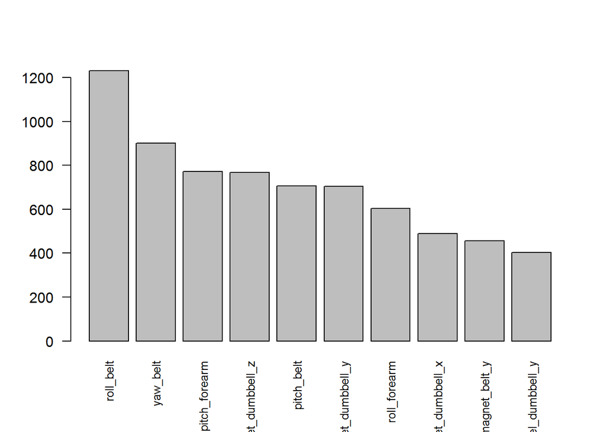

```r
imp <- varImp(final.mod)
ord <- order(imp$Overall,decreasing=TRUE)
imp.first <- imp[ord[1:10],,drop=FALSE]
barplot(imp.first$Overall,names=rownames(imp.first),las=2,cex.names=.8)
```

### Testing

I now load the test set to submit my predictions.

```r
testing <- read.csv("pml-testing.csv",row.names=1)
pred.test <- predict(final.mod,testing)
pred.df <- data.frame(problem_id=testing$problem_id,classe=pred.test)
write.csv(pred.df,"predictions.csv")
```